# Análise Exploratória de Dados: iFood

Bruno Kenzo

17 de maio de 2021

# 1 iFood!

Esta análise é uma continuação de um processo que envolveu a coleta de dados via Web Scraping[^1] e junção de outros conjuntos de dados coletados do [site do iFood](https://www.ifood.com.br/).  
Você pode ver todo o processo no [meu repositório](https://github.com/KenzoBH/Web-Scraping-and-EDA-iFood) no GitHub.  
- [Bruno Kenzo](https://kenzobh.github.io/).

# 2 Introdução

Nessa análise exploratória de dados, irei explorar os dados coletados de 118 restaurantes e alguns aspectos relacionados a eles na plataforma online da iFood.

[figure not shown]

## 2.1 Importando pacotes e dados

Os dados utilizados estão disponíveis no repositório já citado anteriormente, em formato `.csv`.

```r
library(tidyverse)  # Biblioteca para manipulação e visualização de dados
library(knitr)      # Melhor visualização de tabelas em Rmd e HTML
library(kableExtra) # Edição estética de tabelas
```

Vou renomear algumas colunas para melhor interpretabilidade.  
Esse é o nosso conjunto de dados:

```r
df <- read_csv('final-ifood-data.csv') # Importação dos dados em .csv
df <- rename(df, Restaurante = `Título`, Taxa = `Preço`, Coletor = Dono)
# Renomeção de colunas para melhor interpretação

df %>%
    kable() %>%  # Melhor visualização
    kable_styling(full_width = FALSE, # Estéticas
                  bootstrap_options = c('striped', 'hover', 'responsive')) %>%
    scroll_box(width = '100%', height = '500px')
```

| Restaurante | Nota | Tipo | Tempo | Taxa | Coletor |
| --- | --- | --- | --- | --- | --- |
| FILHO DA FRUTA “RESTAURANTE” | 4.7 | Brasileira | 45 | 0.00 | Alexandre Felix |
| Ponto da Esfiha Itapevi | 4.1 | Pizza | 50 | 5.00 | Alexandre Felix |
| Sodiê Doces - Itapevi Jardim da Rainha | 4.6 | Doces & Bolos | 85 | 7.00 | Alexandre Felix |
| 🍔lanches Bem Bolado🍔 | 4.9 | Lanches | 65 | 7.99 | Alexandre Felix |
| Japa House | 4.5 | Japonesa | 65 | 5.00 | Alexandre Felix |
| Gordão Lanches e Açai | 4.5 | Lanches | 65 | 8.99 | Alexandre Felix |
| Los Manos | 4.8 | Lanches | 85 | 12.00 | Alexandre Felix |
| Mc Burgueria e Pizzaria | 4.3 | Pizza | 50 | 8.00 | Alexandre Felix |
| Ra Burger | 4.8 | Lanches | 45 | 0.00 | Alexandre Felix |
| Canto da Esfiha | 4.7 | Lanches | 65 | 5.00 | Alexandre Felix |
| S&q Doces | 4.9 | Doces & Bolos | 85 | 8.00 | Alexandre Felix |
| Cantinho da Dora e Pezao | 4.9 | Lanches | 45 | 3.00 | Alexandre Felix |
| Em Familia Lanchonete | 4.9 | Lanches | 65 | 5.00 | Alexandre Felix |
| La Ville - Aldeia da Serra | 4.5 | Portuguesa | 65 | 17.00 | Alexandre Felix |
| Mc Pizzaria e Burgueria | 4.0 | Pizza | 55 | 0.00 | Alexandre Felix |
| Copo da Felicidade e Hot-dog | 4.1 | Doces & Bolos | 35 | 4.99 | Alexandre Felix |
| Sk. Sushi Kyodai | 0.0 | Japonesa | 75 | 5.00 | Alexandre Felix |
| Restaurante Recanto São Judas | 4.6 | Brasileira | 55 | 6.00 | Alexandre Felix |
| Bistrô Lázara Beer | 4.5 | Brasileira | 65 | 4.00 | Alexandre Felix |
| Mundi Batataria | 4.2 | Lanches | 55 | 5.00 | Alexandre Felix |
| Parceirao Bebidas 1 | 4.6 | Bebidas | 45 | 6.00 | Alexandre Felix |
| Laricas Burg’s | 4.3 | Lanches | 35 | 2.00 | Alexandre Felix |
| Trilha em Sabor | 4.9 | Lanches | 50 | 7.00 | Alexandre Felix |
| Habib’s - Itapevi | 3.8 | Lanches | 53 | 8.90 | Alexandre Felix |
| Tapiocaria Vovo Lili | 4.8 | Lanches | 65 | 7.00 | Alexandre Felix |
| Fogas Búrguer | 0.0 | Lanches | 55 | 4.00 | Alexandre Felix |
| Santana Grill | 0.0 | Brasileira | 45 | 3.00 | Alexandre Felix |
| Brownie do Heuris | 4.9 | Doces & Bolos | 55 | 8.00 | Alexandre Felix |
| Miê Temakeria | 4.5 | Japonesa | 75 | 7.00 | Alexandre Felix |
| Fritinho | 4.1 | Salgados | 50 | 0.00 | Alexandre Felix |

[output cut: 88 more lines]

Nosso dataframe possui 118 linhas e 6 colunas, as quais representam:

- **Restaurante**: nome do restaurante
- **Nota**: média das notas fornecidas pelos usuários no site sobre o restaurante, de 0 a 5
- **Tipo**: tipo de comida que é vendida pelo restaurante
- **Tempo**: tempo médio de entrega (em minutos) até a localização daquele que coletou o dado
- **Taxa**: taxa fixa do frete, em R$
- **Coletor**: aquele que coletou o dado

Sobre as principais medidas estatísticas de cada coluna:

```r
options(knitr.kable.NA = '')

df %>%
    summary() %>% # Principais medidas estatísticas
    kable() %>%
    kable_styling(full_width = FALSE,
                  bootstrap_options = c('striped', 'hover', 'responsive'))
```

|  | Restaurante | Nota | Tipo | Tempo | Taxa | Coletor |
| --- | --- | --- | --- | --- | --- | --- |
|  | Length:118 | Min. :0.000 | Length:118 | Min. : 21.00 | Min. : 0.000 | Length:118 |
|  | Class :character | 1st Qu.:4.200 | Class :character | 1st Qu.: 35.00 | 1st Qu.: 4.000 | Class :character |
|  | Mode :character | Median :4.500 | Mode :character | Median : 45.00 | Median : 6.000 | Mode :character |
|  |  | Mean :4.076 |  | Mean : 48.61 | Mean : 6.586 |  |
|  |  | 3rd Qu.:4.700 |  | 3rd Qu.: 55.00 | 3rd Qu.: 8.998 |  |
|  |  | Max. :5.000 |  | Max. :125.00 | Max. :22.000 |  |

Percebe-se que há restaurantes com nota 0. São novos restaurantes na plataforma - informação que foi obtida na coleta de dados. Irei omitir análises relacionadas com a coluna `Tempo`, uma vez que ela é relativa à localização de cada pessoa que coletou os dados.

Vamos para a análise!

# 3 Notas dos Restaurantes

Primeiramente, veremos quais são os restaurantes com nota máxima.

```r
melhores_restaurantes <- df %>%
    filter(Nota == 5) %>% # Apenas com nota 5
    select(Restaurante) %>% # Apenas a coluna 'Título'
    c() # Juntar em um vetor

annotation = str_c(melhores_restaurantes[[1]][1], ' e ', melhores_restaurantes[[1]][2]) # Já tinha visto que haviam apenas 2 restaurante com nota 5
print(annotation)
```

```
## [1] "Cacau Show - Carrefour Jacu Pessêgo e Jakes Food"
```

Vamos ver mais informações sobre esses dois restaurantes.

```r
df %>%
    filter(Nota == 5) %>%
    kable(caption = "Melhores restaurantes") %>%
    kable_styling(full_width = FALSE,
                  bootstrap_options = c('striped', 'hover', 'responsive'))
```

Melhores restaurantes

| Restaurante | Nota | Tipo | Tempo | Taxa | Coletor |
| --- | --- | --- | --- | --- | --- |
| Cacau Show - Carrefour Jacu Pessêgo | 5 | Doces & Bolos | 31 | 9 | Emerson Aragão |
| Jakes Food | 5 | Lanches | 45 | 0 | Marco Rodrigues |

Nota-se que um deles - *Jakes Food* - tem frete grátis. Será que os usuários levam o preço da taxa de entrega em conta na hora da avaliação? Veremos isso mais pra frente.  
Vamos ver a distribuição das notas não nulas.

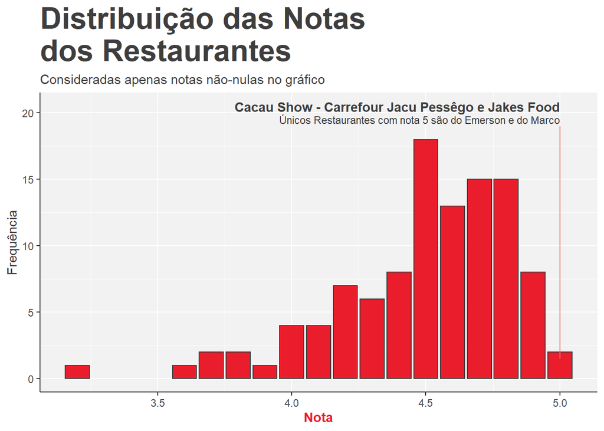

```r
red <- '#EA1D2C'
black <- '#3F3E3E'
grey <- '#F2F2F2'

my_theme <- theme(plot.title = element_text(color = black, size = 25, face = 'bold',),
                  plot.subtitle = element_text(color = black),
                  axis.title.x = element_text(color = red, face = 'bold'),
                  axis.title.y = element_text(color = black),
                  panel.background = element_rect(fill = grey),
                  axis.line = element_line(colour = black),
                  legend.position = 'none')

df %>%
    filter(Nota > 0) %>% # Apenas notas não nulas
    ggplot(aes(x = Nota)) +
    geom_bar(fill = red, color = black) + # Optei por um gráfico de barras
    geom_segment(aes(x = 5, y = 1.5, xend = 5, # Adiciona uma linha vertical
                     yend = 19, color = black)) +
    annotate('text', label = annotation, x = 5, y = 20.5, # Adiciona um texto
             hjust = 'right', fontface = 'bold', color = black) +
    annotate('text', x = 5, y = 19.5,hjust = 'right', color = black, size = 3,
             label = 'Únicos Restaurantes com nota 5 são do Emerson e do Marco') +
    labs(title = 'Distribuição das Notas\ndos Restaurantes',          # Definição do título,
         subtitle = 'Consideradas apenas notas não-nulas no gráfico', # do subtítulo,
         x = 'Nota', y = 'Frequência') +                              # e dos eixos
    my_theme
```

Nota-se que é uma distribuição assimétrica à esquerda[^2]. A moda da distribuição é a nota 4,5.[^3] Ademais, há um restaurante com uma nota abaixo da maioria dos outros, é um ponto isolado do gráfico, com uma nota abaixo de 3,5. Vamos ver qual é esse restaurante, e ver os com nota 0 também.

```r
df %>%
    filter(Nota < 3.5) %>% # Filtrar as notas menores que 3,5
    mutate(
        Nota = cell_spec(Nota, "html", color = ifelse(Nota > 0, red, black))
    ) %>% # Colorir as notas maiores que 0 (apenas uma)
    arrange(desc(Nota)) %>%  # Ordenar pelas notas de forma decrescente
    kable("html", escape = F, caption = 'Restaurantes com notas menores que 3,5') %>%
    kable_styling(full_width = FALSE,
                  bootstrap_options = c('striped', 'hover', 'responsive'))
```

Restaurantes com notas menores que 3,5

| Restaurante | Nota | Tipo | Tempo | Taxa | Coletor |
| --- | --- | --- | --- | --- | --- |
| Jama Masjid | 3.2 | Indiana | 35 | 0.00 | Marco Rodrigues |
| Sk. Sushi Kyodai | 0 | Japonesa | 75 | 5.00 | Alexandre Felix |
| Fogas Búrguer | 0 | Lanches | 55 | 4.00 | Alexandre Felix |
| Santana Grill | 0 | Brasileira | 45 | 3.00 | Alexandre Felix |
| Lancheria Original Brasil Santana | 0 | Açaí | 27 | 6.99 | Emanuel Hark |
| Pizzaria e Esfiharia Massa Mania | 0 | Brasileira | 55 | 15.00 | Marco Rodrigues |
| Riviera Delivery | 0 | Brasileira | 35 | 4.00 | Marco Rodrigues |
| Adega Capão Redondo | 0 | Bebidas | 65 | 10.00 | Marco Rodrigues |
| Fideles Lanches e Doces | 0 | Variada | 55 | 0.00 | Marco Rodrigues |
| Mc favela João dias | 0 | Lanches | 95 | 15.00 | Marco Rodrigues |
| pizzaria ducheff | 0 | Pizza | 40 | 0.00 | Marco Rodrigues |
| Burguer Store | 0 | Lanches | 125 | 13.00 | Marco Rodrigues |

# 4 Sobre as Taxas

Vamos ver a distribuição das taxas

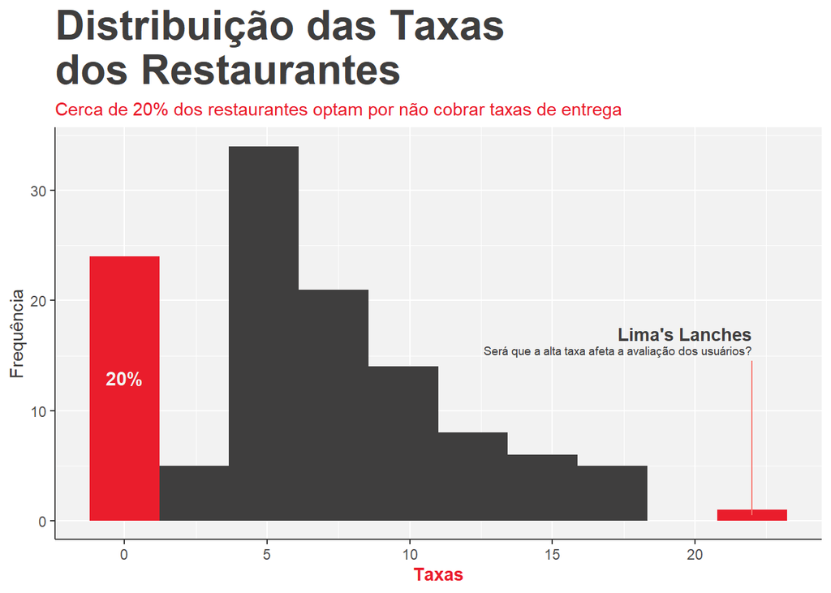

```r
df %>% # Optei por um histograma, pois é uma variável contínua
    ggplot(aes(x = Taxa, fill = (Taxa == 0 | Taxa > 20))) +
    geom_histogram(bins = 10) +
    scale_fill_manual(values = c(black, red)) +
    geom_segment(aes(x = 22, y = 0.5, xend = 22, # Adiciona uma linha vertical
                     yend = 14.5, color = black)) +
    annotate('text', label = '20%', x = 0, y = 13, # Adiciona um texto
             hjust = 'center', fontface = 'bold', size = 4, color = grey) +
    annotate('text', label = "Lima's Lanches", x = 22, y = 17, # Adiciona um texto
             hjust = 'right', fontface = 'bold', color = black) +
    annotate('text', label = 'Será que a alta taxa afeta a avaliação dos usuários?',
             x = 22, y = 15.5, hjust = 'right', color = black, size = 2.5) +
    labs(title = 'Distribuição das Taxas\ndos Restaurantes', # Definição do título,
         subtitle = 'Cerca de 20% dos restaurantes optam por não cobrar taxas de entrega',
         x = 'Taxas', y = 'Frequência') +                    # e dos eixos
    my_theme +
    theme(plot.subtitle = element_text(color = red))  # Subtítulo em vermelho
```

Dessa distribuição, nota-se diversas peculiaridades. Muitos restaurantes não cobram taxa de entrega. De forma mais específica, 24 restaurantes.  
Ademais, são poucos aqueles que cobram menos que R$5,00 - talvez não valha a pena cobrar uma taxa pequena, pois pode ser mais estratégico não cobrar taxa alguma e mostar-se mais atraente a possíveis clientes.

Sobre o ponto isolado com taxa de R$22,00: o restaurante é Lima’s Lanches, sua nota é 4.7. Talvez, a taxa não influencie tanto na avaliação dos clientes, e sim o sabor da comida. Ou, talvez, os lanches do Lima’s Lanches valham à pena a alta taxa. Veremos:

```r
df %>%
    mutate(Taxa = ifelse(Taxa <= 5, 'Barata', 'Cara')) %>%
    group_by(Taxa) %>%
    summarise('Média das Notas' = mean(Nota)) %>%
    kable(caption = 'Sobre a influência da taxa nas notas dos restaurantes') %>%
    kable_styling(full_width = FALSE,
                  bootstrap_options = c('striped', 'hover', 'responsive'))
```

Sobre a influência da taxa nas notas dos restaurantes

| Taxa | Média das Notas |
| --- | --- |
| Barata | 3.886792 |
| Cara | 4.230769 |

Considerei baratas aquelas taxas que são menores ou iguais a R$5,00, e caras as que não. Ao que indica, os restaurantes que cobram altas taxas são restaurantes mais bem-avaliados - talvez por entregarem uma comida de mais alto nível.  
Vejamos a distribuição das taxas em função das notas:

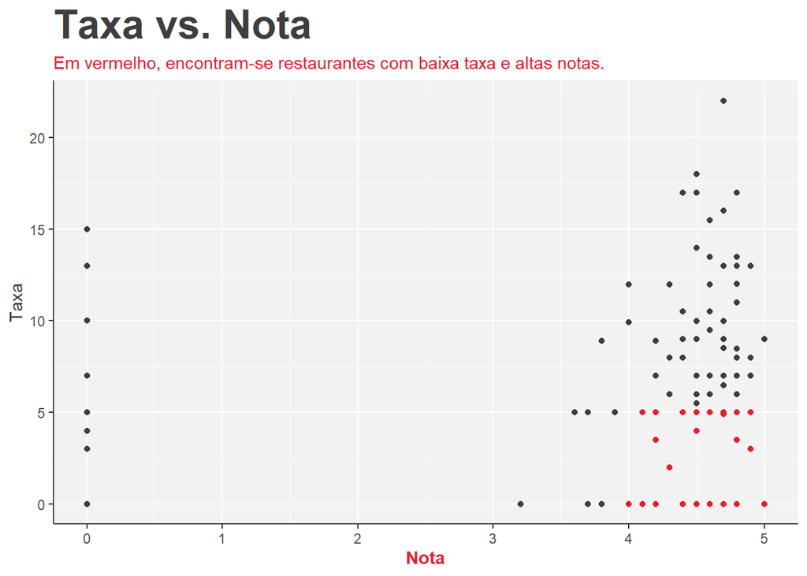

```r
df %>%
    ggplot(aes(y = Taxa, x = Nota, color = (Taxa <= 5 & Nota >= 4))) +
    scale_color_manual(values = c(black, red)) +
    geom_point() +
    labs(title = 'Taxa vs. Nota',
         subtitle = 'Em vermelho, encontram-se restaurantes com baixa taxa e altas notas.') +
    my_theme +
    theme(plot.subtitle = element_text(color = red))
```

Esperava que os restaurantes com menor taxa seriam melhores avaliados. Porém, como visto no gráfico de dispersão acima, não parece ter uma relação entre a taxa e a nota do restaurante.  
Há 24 restaurantes que não cobram taxa dentre os 118.

Parece, portanto, que a taxa de frete não impacta a avaliação do restaurante.

# 5 Dos Tipos

Vejamos a distribuição dos restaurantes agrupados por tipo de comida:

## 5.1 Desconsiderando notas 0

```r
df %>%
    filter(Nota > 0) %>%
    group_by(Tipo) %>%
    summarise(Quantidade = n(), `Taxa Média` = mean(Taxa),
              `Nota Média` = mean(Nota)) %>%
    arrange(desc(`Nota Média`)) %>%
    kable(caption = 'Restaurantes agrupados por tipo', 'html') %>%
    kable_styling(full_width = FALSE,
                  bootstrap_options = c('striped', 'hover', 'responsive')) %>%
    scroll_box(width = '55%', height = '300px',
               extra_css = 'margin-left: 50%; transform: translateX(-50%); ')
```

Restaurantes agrupados por tipo

| Tipo | Quantidade | Taxa Média | Nota Média |
| --- | --- | --- | --- |
| Coreana | 2 | 10.490000 | 4.850000 |
| Italiana | 2 | 11.490000 | 4.750000 |
| Chinesa | 1 | 8.500000 | 4.700000 |
| Saudável | 2 | 9.990000 | 4.700000 |
| Bebidas | 4 | 9.122500 | 4.650000 |
| Doces & Bolos | 9 | 7.051111 | 4.600000 |
| Lanches | 31 | 7.280000 | 4.583871 |
| Japonesa | 13 | 7.380000 | 4.569231 |
| Brasileira | 8 | 4.560000 | 4.500000 |
| Padaria | 1 | 5.990000 | 4.500000 |
| Portuguesa | 1 | 17.000000 | 4.500000 |
| Açaí | 3 | 9.326667 | 4.400000 |
| Árabe | 1 | 10.490000 | 4.400000 |
| Pizza | 19 | 3.308947 | 4.384211 |
| Variada | 1 | 3.500000 | 4.200000 |
| Hambúrguer | 4 | 6.970000 | 4.150000 |
| Salgados | 4 | 3.747500 | 4.075000 |
| Indiana | 1 | 0.000000 | 3.200000 |

Comidas coreanas se destacam dentre os tipos de comida - porém, se referem a apenas 2 restaurantes: Komah Por Paulo Shin, Joy Korean Food. Destaque para Doces & Bolos, que possuem uma alta nota média com 9 restaurantes.

## 5.2 Considerando notas 0

```r
df %>%
    group_by(Tipo) %>%
    summarise(Quantidade = n(), `Taxa Média` = mean(Taxa),
              `Nota Média` = mean(Nota)) %>%
    arrange(desc(`Nota Média`)) %>%
    kable(caption = 'Restaurantes agrupados por tipo') %>%
    kable_styling(full_width = FALSE,
                  bootstrap_options = c('striped', 'hover', 'responsive')) %>%
    scroll_box(width = '55%', height = '300px',
               extra_css = 'margin-left: 50%; transform: translateX(-50%); ')
```

Restaurantes agrupados por tipo

| Tipo | Quantidade | Taxa Média | Nota Média |
| --- | --- | --- | --- |
| Coreana | 2 | 10.490000 | 4.850000 |
| Italiana | 2 | 11.490000 | 4.750000 |
| Chinesa | 1 | 8.500000 | 4.700000 |
| Saudável | 2 | 9.990000 | 4.700000 |
| Doces & Bolos | 9 | 7.051111 | 4.600000 |
| Padaria | 1 | 5.990000 | 4.500000 |
| Portuguesa | 1 | 17.000000 | 4.500000 |
| Árabe | 1 | 10.490000 | 4.400000 |
| Japonesa | 14 | 7.210000 | 4.242857 |
| Lanches | 34 | 7.578824 | 4.179412 |
| Pizza | 20 | 3.143500 | 4.165000 |
| Hambúrguer | 4 | 6.970000 | 4.150000 |
| Salgados | 4 | 3.747500 | 4.075000 |
| Bebidas | 5 | 9.298000 | 3.720000 |
| Açaí | 4 | 8.742500 | 3.300000 |
| Brasileira | 11 | 5.316364 | 3.272727 |
| Indiana | 1 | 0.000000 | 3.200000 |
| Variada | 2 | 1.750000 | 2.100000 |

Comidas coreanas se destacam dentre os tipos de comida - porém, se referem a apenas 2 restaurantes: Komah Por Paulo Shin, Joy Korean Food. Destaque para Doces & Bolos, que possuem uma alta nota média com 9 restaurantes, e comida Brasileira, que possui 11 restaurantes com nota média de 3,27.

# 6 Conclusão

Nota-se, portanto, que dos 118 estabelecimentos analisados, a maioria possui uma alta avaliação no site da plataforma. Porém, encontram-se alguns pontos isolados com notas abaixo do esperado - Jama Masjid com nota 3,2 e outros 11 restaurantes com nota 0, pois são novos no iFood.

Os 2 melhores restaurantes dentro os coletados são Cacau Show - Carrefour Jacu Pessêgo e Jakes Food, com nota 5 - seria interessante coletar a quantidade de avaliações dos mesmos.

Ademais, notou-se também que muitos restaurantes optam por não cobrar taxas de frete, o que não pareceu impactar na avaliação dos usuários. E destaque para os restaurantes de comida coreana, que obtiveram a maior média das avaliações no iFood (porém, com apenas 2 restaurantes).

## 6.1 Contato

Veja todo o processo desse projeto [neste repositório](https://github.com/KenzoBH/Web-Scraping-and-EDA-iFood).  
Para entrar em contato comigo, use qualquer um desses meios:

[Website](https://kenzobh.github.io/)  
Email: brunokenzoh@usp.br  
LinkedIn/[bruno-kenzo](https://www.linkedin.com/in/bruno-kenzo/)  
GitHub/KenzoBH

Obrigado pela leitura! :D  
- *Kenzo.*

[^1]: Web Scraping, ou “Raspagem da Web”, é o processo de coletar dados de sites da internet. Utilizei bibliotecas específicas para esse processo - Selenium - em linguagem Python e conhecimentos de HTML.
[^2]: Uma distribuição assimétrica à esquerda é aquela em que os dados so concentram em um valor acima da média amostral, formando um histograma semelhante a uma subida de colina da esquerda para a direita.
[^3]: A moda de uma distribuição é o valor mais frequente da mesma. Há distribuições que podem ter mais de uma moda - distribuições bimodais, trimodais, etc.